| National Park Service U.S. Department of the Interior Natural Resource Stewardship and Science |  |
| --- | --- |

# 2025 Weather in Review: Assateague Island National Seashore

Weather and climate play significant roles in driving both physical and ecological processes. For example, the active processes that shape the North Atlantic coastline are largely the result of meteorological events such as wind-driven waves. For research and long-term ecological monitoring, weather and climate data provide the potential for correlations to be made with observed physical and ecological pattern data.

This resource brief provides a summary of both historic and current (2025) weather data for Assateague Island National Seashore (ASIS), Maryland (MD) and Virginia (VA). Because tide levels and wind can be significant for coastal parks, the annual water level and wind data are included. Temperature and precipitation data presented in this brief are for Worcester County, Maryland. Data are available from the [National Climate Data Center](https://www.ncei.noaa.gov/access/monitoring/climate-at-a-glance/county/time-series).

# Temperature

Overall, 2025 was the 23rd warmest year on record with an average temperature of 57.4 °F — 1.4 degrees above average (Figure 1). Spring fell within “much above normal” temperatures, winter and summer fell within “above normal temperatures”, and fall fell within “near normal” temperatures. 2025 had the 3rd warmest spring on record. The warmest month was July with an average of 79.7 degrees — 3.3 degrees over the monthly average. Nine out of twelve months had higher than average temperatures. Only January, August, and December had lower than average monthly temperatures (Table 1).

| Month (2025) | Average temperature (°F) | Departure from long-term average temperature (°F) |
| --- | --- | --- |
| January | 32.6 | −3.8 |
| February | 39.4 | +2.3 |
| March | 50.0 | +5.7 |
| April | 57.6 | +4.4 |
| May | 65.7 | +2.9 |
| June | 75.6 | +4.2 |
| July | 79.7 | +3.3 |
| August | 72.4 | −2.8 |
| September | 69.9 | +0.6 |
| October | 59.2 | +0.4 |
| November | 49.0 | +0.8 |
| December | 37.3 | −2.2 |
| Annual | 57.4 | +1.4 |

Table 1. Worcester County, Maryland average monthly, average annual, and departures from long-term average temperatures. Departures from average are based on a comparison of 2025 average temperatures to relevant averages from 1895-2024. Data are available at NOAA NCEI: Climate at a Glance (https://www.ncdc.noaa.gov/cag/county/time-series/MD-047/tavg/all/12/2025-2025).

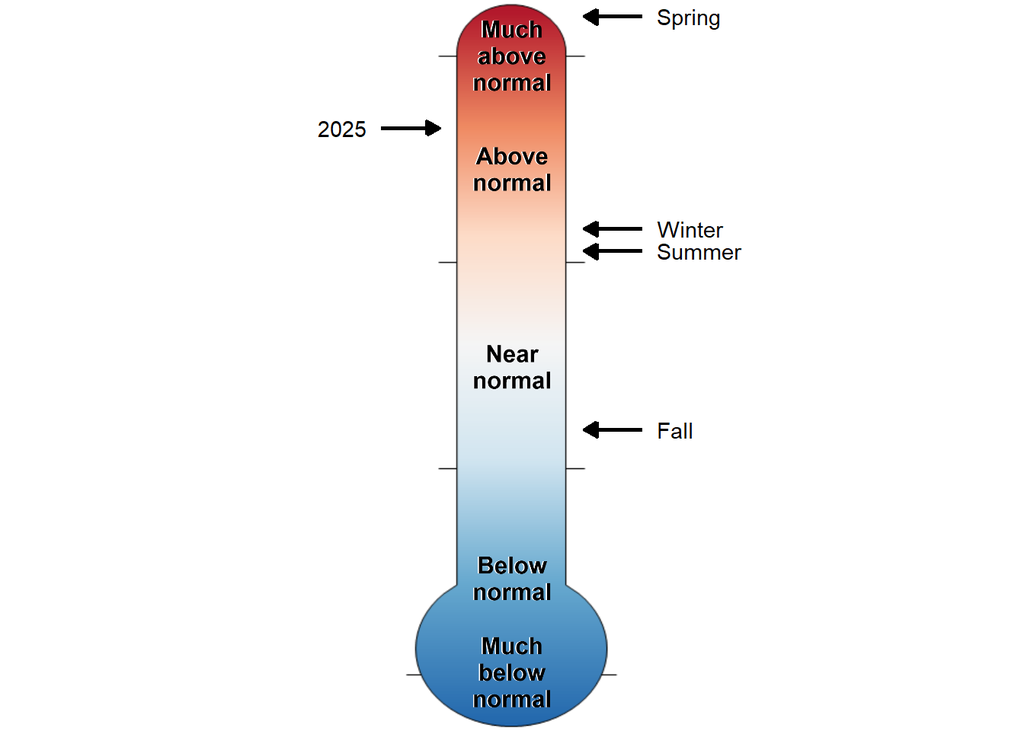

Figure 1: Worcester County, Maryland annual and seasonal temperature rankings from 1895-2025. Of the 131 records, 2025 was the 23rd warmest year. Seasonally, it was the 41st warmest winter, 3rd warmest spring, 45th warmest summer, and the 55th coldest fall. Data are available at NOAA NCEI: Climate at a Glance (https://www.ncdc.noaa.gov/cag/county/rankings/MD-047/tavg/202512).

# Precipitation

| Month (2025) | Total precipitation (in) | Departure from long-term average precipitation (in) |
| --- | --- | --- |
| January | 1.96 | −1.53 |
| February | 4.47 | +1.13 |
| March | 5.06 | +1.02 |
| April | 4.02 | +0.71 |
| May | 5.22 | +1.89 |
| June | 3.14 | −0.42 |
| July | 5.79 | +1.52 |
| August | 2.31 | −2.25 |
| September | 4.01 | +0.41 |
| October | 2.44 | −0.96 |
| November | 1.43 | −1.52 |
| December | 2.03 | −1.44 |
| Annual | 41.88 | −1.44 |

Table 2. Worcester County, Maryland monthly and annual total precipitation and departures from long-term average totals. Departures from average are based on a comparison of 2025 precipitation levels to relevant averages from 1895-2024. Data are available at NOAA NCEI: Climate at a Glance (https://www.ncdc.noaa.gov/cag/county/time-series/MD-047/pcp/all/12/2025-2025)

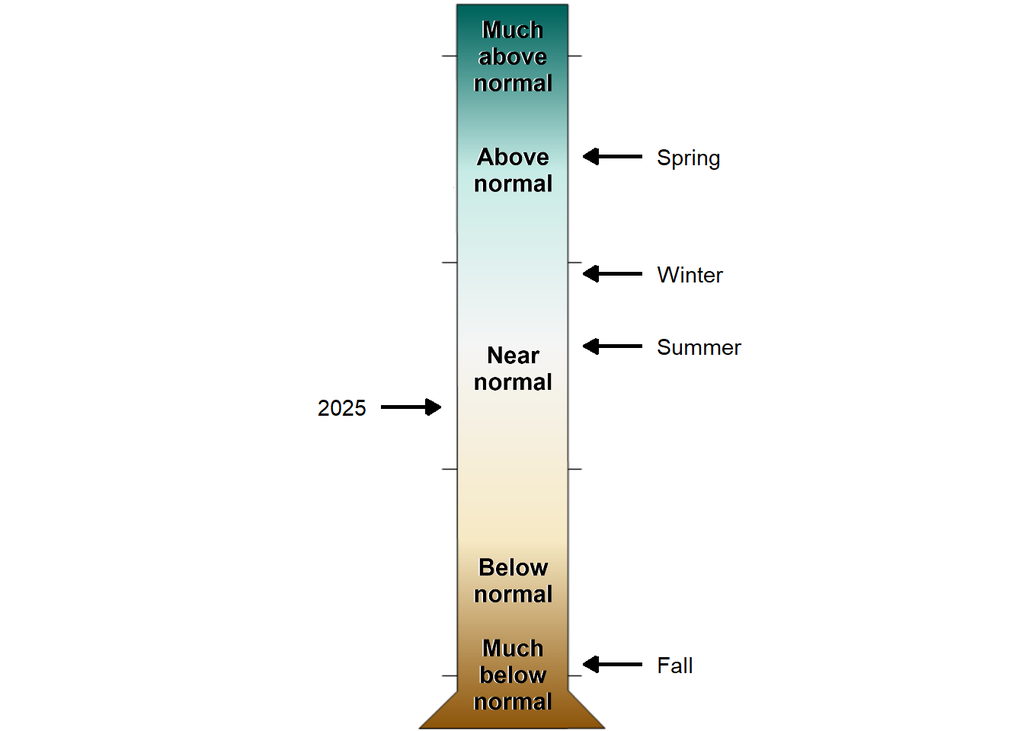

Figure 2: Worcester County, Maryland annual and seasonal precipitation rankings from 1895-2025. Of the 131 records, 2025 was the 59th driest year. Seasonally, it was the 49th wettest winter, 28th wettest spring, 62nd wettest summer, and the 13th driest fall. Data are available at NOAA NCEI: Climate at a Glance (https://www.ncdc.noaa.gov/cag/county/rankings/MD-047/pcp/202512).

# Temperature and Precipitation Trends (1895-2025)

Temperature and precipitation data are gathered from the [U.S. Climate Divisional Database](https://www.ncei.noaa.gov/access/monitoring/reference-maps/conus-climate-divisions), which stores data from January 1895 to the present, and can be accessed via the National Oceanic and Atmospheric Administration’s (NOAA) [National Centers for Environmental Information](https://www.ncei.noaa.gov/access/monitoring/climate-at-a-glance/county/time-series) (NCEI) website (Figure 3). Users can choose different geographic scales (i.e., global, national, statewide), different temporal scales, and display them in various types of graphical formats.

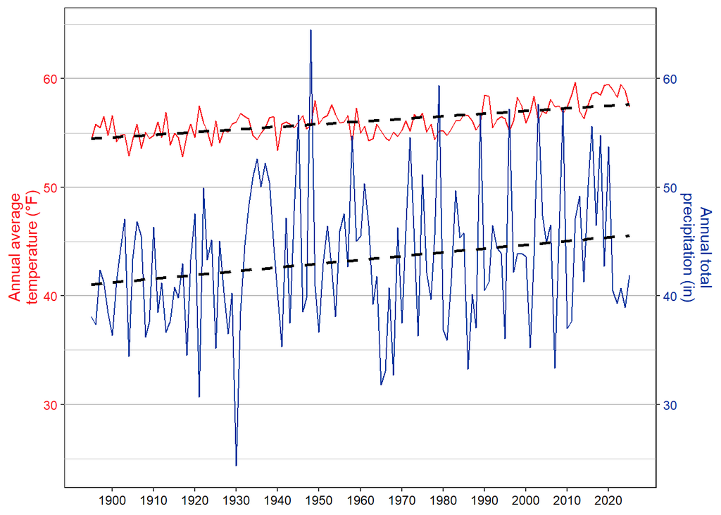

Figure 3: Worcester County, Maryland yearly average temperature and precipitation from 1895 to 2025. Dashed lines represent the 1895-2025 trend for each parameter; +0.2°F/decade for temperature and +0.35 in/decade for precipitation. Data are available at NOAA NCEI: Climate at a Glance (https://www.ncdc.noaa.gov/cag/county/time-series/).

## Tide Levels

Water level data is collected from NOAA National Water Level Observation Network (NWLON) station 8570283 located at the inlet of Ocean City, MD. This station has records dating back to 1978. The data is graphed to show the difference in the predicted tide level verses what was observed (Figure 4). The offsets in height reflect the effect from storm surge on the normal, astronomically driven tide level.

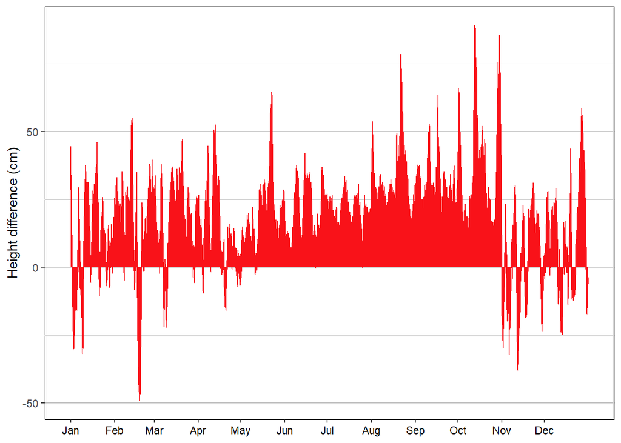

Figure 4: This bar graph depicts the difference in the predicted and observed tide levels at the inlet of Ocean City, MD for 2025. Data are available at NOAA Tides & Currents (https://tidesandcurrents.noaa.gov/stationhome.html?id=8570283).

# Wind

Wind data (wind speed and direction) is collected from the NOAA NWLON station 8570283 located at the inlet of Ocean City, MD. Each direction is divided up into categories called bins that are color coded to represent the frequency of a certain wind speed. The length of the bin represents the number of times wind comes from a given direction as well as the speed of the wind. The longer the length of the bin, the more frequent the given speed was recorded (Figure 5).

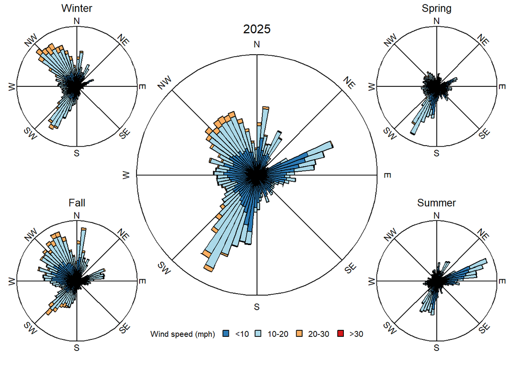

Figure 5: Wind charts reflecting both the seasonal and annual wind direction and speed at the NOAA NWLON station 8570283 located at the inlet of Ocean City, MD during 2025. Data are available at NOAA Tides & Currents (https://tidesandcurrents.noaa.gov/stationhome.html?id=8570283).